# Smacof at 50 A Manual

Jan de Leeuw - University of California Los Angeles

Started February 21 2024, Version of March 27, 2024

Abstract

**Note:** This is a working paper which will be expanded/updated frequently. All suggestions for improvement are welcome. All Rmd, tex, html, pdf, R, and C files are in the public domain. Attribution will be appreciated, but is not required. The files can be found at https://github.com/deleeuw/smacofCode.

# 1 Introduction

In *Multidimensional Scaling (MDS)* the data consists of information about the similarity or dissimilarity between pairs of objects selected from a finite set $\mathcal{O}=\{o_1,\cdots,o_n\}$.

In *metric MDS* we have numerical dissimilarity measures and we want to map the objects $o_i$ into $n$ points $x_i$ of some metric space in such a way that the distances between the points approximate the dissimilarities between the objects. In *smacof*, our framework for MDS theory, algorithms, and computer programs, the metric space is $\mathbb{R}^p$, the space of all $p$-tuples of real numbers, and in the code documented in this manual we assume the distance is the usual Euclidean distance.

In *non-metric MDS* the information about the dissimilarities is incomplete. It is usually *ordinal*, i.e. it tells us in some way or another that some dissimilarties are larger or smaller than others. Somewhere between metric and non-metric MDS is MDS with *missing data*, in which some dissimilarities are known numbers while others are unknown. MDS with missing data is a form of *distance matrix completion* (Fang and O’Leary (2012)).

## 1.1 Kruskal’s Stress

The weights $w_{ij}$ can be used to quantify information about the precision or importance of the corresponding dissimilarities. Some of the weights may be zero, which can be used to code *missing data*. If all weights are positive we have *complete data*. If we have complete data, and all weights are equal to one, we have *unweighted* metric MDS. Weights were only introduced in MDS in De Leeuw (1977), the pioneering papers by Shepard, Kruskal, and Guttman only consider the unweighted case.

We assume throughout that the weights are *irreducible* (De Leeuw (1977)). This means there is no partitioning of the index set $I_n:=\{1,2,\cdots,n\}$ into subsets for which all between-subset weights are zero. A reducible metric MDS problems decomposes into a number of smaller independent metric MDS problems, so the irreducibility assumption causes no real loss of generality.

In non-metric MDS the loss function becomes
$$\begin{equation}
\sigma(X,\hat D):=\frac12\sum w_{ij}(\hat d_{ij}-d_{ij}(X))^2,
\tag{1.2}
\end{equation}$$
where $\hat D$ are now the quantified or transformed dissimilarities. In MDS parlance they are also called *pseudo-distances* or *disparities*. Loss function (1.2) must be minimized over both configurations and disparities, with the condition that the disparities $\hat D$ are an admissible transformation of the dissimilarities $\Delta$. In Kruskal’s non-metric MDS this means requiring monotonicity. In this paper we will consider various other choices for the set of admissible transformations. We will use the symbol $\mathfrak{D}$ for the set of admissible transformations

The most familiar sets of admissible transformations (linear, polynomial, monotone) define convex cones with apex at the origin. This means that if $\hat D\in\mathfrak{D}$ then so is $\lambda\hat D$ for all $\lambda\geq 0$. But consequently minimizing (1.2) over all $\hat D\in\mathfrak{D}$ and over all configurations has the trivial solution $\hat D=0$ and $X=0$, corresponding with the global minimum $\sigma(X,\hat D)=0$. We need additional constraints to rule out this trivial solution, and in non-metric MDS this is done by choosing a *normalization* that keeps the solution away from zero.

Kruskal’s solution is to normalize the raw stress by defining
$$\begin{equation}
\sigma(X,\Delta):=\frac{\sum w_{ij}(\hat d_{ij}-d_{ij}(X))^2}{\sum w_{ij}d_{ij}^2(X)}.
\tag{1.3}
\end{equation}$$
In fact in Kruskal’s formulation there are no weights, and he actually takes the square root of (1.3) to define *Kruskal’s stress*. The non-metric Euclidean MDS problem is to minimize loss function (1.3) over all $n\times p$ configurations $X$ and all admissible disparities $\Delta$.

## 1.2 Normalization

Normalization in non-metric MDS has been discussed in detail in Kruskal and Carroll (1969) and De Leeuw (1975). In the terminology of De Leeuw (1975) there are *explicit* and *implicit* normalizations.

In implicit normalization we minimize either
$$\begin{equation}
\sigma(X,\hat D):=\frac{\sum w_{ij}(\hat d_{ij} -d_{ij}(X))^2}{\sum w_{ij}^{\ }\hat d_{ij}^2}
\tag{1.4}
\end{equation}$$
or
$$\begin{equation}
\sigma(X,\hat D):=\frac{\sum w_{ij}(\hat d_{ij}-d_{ij}(X))^2}{\sum w_{ij}^{\ }d_{ij}^2(X) }
\tag{1.5}
\end{equation}$$
Kruskal (1964a) chooses definition (1.5) and calls the explicitly normalized loss function *normalized stress*. In fact, he takes the square root, which does not change the minimization problem, and only considers the unweighted case. Note that we overload the symbol $\sigma$ to denote any one of the least squares loss functions. It will always be clear from the text which $\sigma$ we are talking about.

In explicit normalization we minimize the raw stress $\sigma(X,\hat D)$ from (1.2), but we add the constraint
$$\begin{equation}
\sum w_{ij}^{\ }d_{ij}^2(X)=1,
\tag{1.6}
\end{equation}$$
or the constraint
$$\begin{equation}
\sum w_{ij}^{\ }\hat d_{ij}^2=1.
\tag{1.7}
\end{equation}$$
Kruskal and Carroll (1969) and De Leeuw (2019) show that these four normalizations all lead to essentially the same solution for $X$ and $\hat D$, up to scale factors dictated by the choice of normalization. It is also possible to normalize both $X$ and $\hat D$, either explicitly or implicitly, and again this will give the same solutions, suitably normalized. These invariance results assume the admissible transformations form a closed cone with apex at the origin, i.e. if $\hat D$ is admissible and $\lambda\geq 0$ then $\lambda\hat D$ is admissible as well. The matrices of Euclidean distances $D(X)$ form a similar closed cone as well. The LSNE-MDS problem is to find an element of the $\hat D$ cone and an element of the $D(X)$ cone where the angle between the two is a small as possible.

In the R version of smacof (De Leeuw and Mair (2009), Mair, Groenen, and De Leeuw (2022)) we use explicit normalization (1.7). This is supported by the result, also due to De Leeuw (1975), that projection on the intersection of the cone of disparities and the sphere defined by (1.7) is equivalent to first projecting on the cone and then normalizing the projection (see also Bauschke, Bui, and Wang (2018)).

In our version of non-metric MDS we need more flexibility. For algorithmic reasons that will become clear later on, we will go with the other explicit normalization (1.6) and minimize $\sigma$ from (1.2) over normalized $X$ and unnormalized $\hat D$. For the final results the choice between (1.6) and (1.7) should not make a difference.

## 1.3 Some thoughts on ALS

I will take this opportunity to clear up some misunderstandings and confusions that have haunted the early development of non-metric MDS.

### 1.3.1 The Single-Phase approach

In Kruskal (1964a) defines
$$\begin{equation}
\sigma(X):=\min_{\hat D\in\mathfrak{D}}\ \sigma(\hat D,X)=\sigma(X,\hat D(X)),
\tag{1.8}
\end{equation}$$
where $\sigma(\hat D,X)$ is defined by (1.5). where the minimum is over admissible transformations. In definition (1.8)
$$\begin{equation}
\hat D(X):=\mathop{\text{argmin}}_{\hat D\in\mathfrak{D}}\sigma(X, \hat D).
\tag{1.9}
\end{equation}$$
Normalized stress defined by (1.8) is now a function of $X$ only. Under some conditions, which are true in Kruskal’s definition of non-metric MDS,
$$\begin{equation}
\mathcal{D}\sigma(X)=\mathcal{D}_1\sigma(X,\hat D(X)),
\tag{1.10}
\end{equation}$$
where $\mathcal{D}\sigma(X)$ are the derivatives of $\sigma$ from (1.8) and $\mathcal{D}_1\sigma(X,\hat D(X))$ are the partial derivatives of $\sigma$ from (1.5) with respect to $X$. Thus the partials of $\sigma$ from (1.8) can be computed by evaluating the partials of $\sigma$ from (1.5) with respect to $X$ at $(X,\hat D(X))$. This has created much confusion in the past. The non-metric MDS problem is now to minimize $\sigma$ from (1.8), which is a function of $X$ alone.

Guttman (1968) calls this the *single-phase approach*. A variation of Kruskal’s single-phase approach defines
$$\sigma(X)=\sum w_{ij}(d_{ij}^\#(X)-d_{ij}(X))^2$$
where the $d_{ij}^\#(X)$ are *Guttman’s rank images*, i.e. the permutation of the $d_{ij}(X)$ that makes them monotone with the $\delta_{ij}$ (Guttman (1968)). Or, alternatively, define
$$\sigma(X):=\sum w_{ij}(d_{ij}^\%(X)-d_{ij}(X))^2$$
where the $\hat d_{ij}^\%(X)$ are *Shepard’s rank images*, i.e. the permutation of the $\delta_{ij}$ that makes them monotone with the $d_{ij}(X)$ (Shepard (1962a), Shepard (1962b), De Leeuw (2017b)).

Minimizing the Shepard and Guttman single-phase loss functions is computationally more complicated than Kruskal’s *monotone regression* approach, mostly because the rank-image transformations are not differentiable, and there is no analog of (1.10) and of the equivalence of the different implicit and explicit normalizations.

### 1.3.2 The Two-Phase Approach

The *two-phase approach* or *alternating least squares (ALS)* approach alternates minimization of $\sigma(\hat D,X)$ over $X$ for our current best estimate of $\hat D$ with minimization of $\sigma(\hat D,X)$ over $\Delta\in\mathfrak{D}$ for our current best value of $X$. Thus an update from iteration $k$ to iteration $k+1$ looks like
$$\begin{align}
\hat D^{(k)}&=\mathop{\text{argmin}}_{\hat D\in\mathfrak{D}}\sigma(\hat D,X^{(k)}),\tag{1.11}\\
X^{(k+1)}&=\mathop{\text{argmin}}_X\sigma(\hat D^{(k)},X).\tag{1.12}
\end{align}$$
This ALS approach to MDS was in the air since the early (unsuccessful) attempts around 1968 of Young and De Leeuw to combine Torgerson’s classic metric MDS method with Kruskal’s monotone regression transformation. All previous implementations of non-metric smacof use the two-phase approach, and we will do the same in this paper.

As formulated, however, there are some problems with the ALS algorithm. Step (1.11) is easy to carry out, using monotone regression. Step (1.12) means solving a metric scaling problem, which is an iterative proces that requires an infinite number of iterations. Thus, in the usual implementations, step (1.11) is combined with one of more iterations of a convergent iterative procedure for metric MDS, such as smacof. If we take only one of these *inner iterations* the algorithm becomes indistinguishable from Kruskal’s single-phase method. This has also created much confusion in the past.

In the usual implementations of the ALS approach we solve the first subproblem (1.11) exactly, while we take only a single step towards the solution for given $\hat D$ in the second phase (1.12). If we have an infinite iterative procedure to compute the optimal $\hat D\in\mathfrak{D}$ for given $X$, then a more balanced approach would be to take several inner iterations in the first phase and several inner iterations in the second phase. How many of each, nobody knows. In our current implementation of smacof we take several inner iteration steps in the first phase and a single inner iteration step in the second phase.

# 2 Smacof Notation and Terminology

We discuss some standard MDS notation, first introduced in De Leeuw (1977). This notation is useful for the second phase of the ALS algorithm, in which solve the metric MDS problem of we minimizing unnormalized $\sigma(X,\hat D)$ over $X$ for fixed $\hat D$. We will discuss the first ALS phase later in the paper.

Start with the unit vectors $e_i$ of length $n$. They have a non-zero element equal to one in position $i$, all other elements are zero. Think of the $e_i$ as the columns of the identity matrix.

Using the $e_i$ we define for all $i\not= j$ the matrices
$$\begin{equation}
A_{ij}:=(e_i-e_j)(e_i-e_j)'.
\end{equation}$$
The $A_{ij}$ are of order $n$, symmetric, doubly-centered, and of rank one. They have four non-zero elements. Elements $(i,i)$ and $(j,j)$ are equal to $+1$, elements $(i,j)$ and $(j,i)$ are $-1$.

The importance of $A_{ij}$ in MDS comes from the equation
$$\begin{equation}
d_{ij}^2(X)=\text{tr}\ X'A_{ij}X.
\tag{2.1}
\end{equation}$$
In addition we use the fact that the $A_{ij}$ form a basis for the $binom{n}{2}$-dimensional linear space of all doubly-centered symmetric matrices.

Expanding the square in the definition of stress gives
$$\begin{equation}
\sigma(X)=\frac12\{\sum w_k\delta_k^2-2\ \sum w_k\delta_kd_k(X)+\sum w_kd_k^2(X)\}.
\tag{2.2}
\end{equation}$$
It is convenient to have notation for the three separate components of stress from equation (2.2). Define
$$\begin{align}
\eta_{\hat D}^2&=\sum w_{ij}\hat d_{ij}^2,\tag{2.3}\\
\rho(X)&=\sum w_{ij}\hat d_{ij}d_{ij}(X),\tag{2.4}\\
\eta^2(X)&=\sum w_{ij}d_{ij}(X)^2.\tag{2.5}
\end{align}$$
which lead to
$$\begin{equation}
\sigma(X)=\frac12\left\{\eta_{\hat D}^2-2\rho(X)+\eta^2(X)\right\}.
\tag{2.6}
\end{equation}$$
We also need
$$\begin{equation}
\lambda(X)=\frac{\rho(X)}{\eta(X)}.
\tag{2.7}
\end{equation}$$

Because $B(X)$ and $V$ are non-negative linear combinations of the $A_{ij}$ they are both positive semi-definite. Because $W$ is assumed to be irreducible the matrix $V$ has rank $n-1$, with only vectors proportional to the vector $e$ with all elements equal to one in its null-space (De Leeuw (1977)).

# 3 Properties of Smacof Loss

## 3.1 Derivatives

$$\mathcal{D}\sigma(X)=(V-B(X))X$$
At a stationary point $B(X)X=VX$ or $V^+B(X)X=X$. Thus a necessary condition for a local minimum is that $V^+B(X)$ has at least $p$ eigenvalues equal to one. De Leeuw (2014) has shown that if $V^+B(X)\lesssim I$ then actually $X$ is a global minimizer of stress.

### 3.1.1 Hessian

The results on the Hessian of stress are largely unpublished. So we summarize them here in this manual, so they’ll be even more unpublished.

$$H_{st}(X):=\sum w_{ij}\frac{\delta_{ij}}{d_{ij}(X)}\left\{\frac{A_{ij}x_sx_t'A_{ij}}{d_{ij}^2(X)}\right\}$$

If $Y=XT$ with $T$ anti-symmetric then $\text{tr}\ Y'A_{ij}X=0$ then thus $H(X)y=0$. Thus
$$\sum_{t=1}^p\mathcal{D}_{st}\sigma(X)y_t=(V-B(X))y_t$$
which is zero if $\mathcal{D}\sigma(X)$ is zero. Thus at a stationary point of stress $\mathcal{D}^\sigma(X)$ has $\frac12p(p-1)$ zero eigenvalues.

There are several ways to think of the Hessian. The simplest one (perhaps) is as an $np\times np$ symmetric matrix (corresponding to

column-major R vector of length $\frac12 np(np+1)$). This is what we would use for a straightforward version of Newton-Raphson.

It is more elegant, however, to think of $H$ as a symmetric super-matrix of order $p$, with as elements $n\times n$ matrices. And, for some purposes, such as the pseudo-confidence ellipsoids in De Leeuw (2017a), as a super-matrix of order $n$ with as elements $p\times p$ matrices. Both the super-matrix interpretations lead to four-dimensional arrays, the first a $p\times p\times n\times n$ array, the second an $n\times n\times p\times p$ array. The different interpretations lead to different ways to store the Hessian in memory, and to different ways to retrieve its elements. Of course we can write routines to transform from one interpretation to another.

## 3.2 Lagrangian

In our implementation of the smacof algorithm we minimize stress over configurations with $\eta(X)=1$, or, equivalently, $\sum w_{ij}d_{ij}^2(X)=1$. This means we do not look for $X$ with $\mathcal{D}\sigma(X)=(V-B(X))X=0$, but we look for solutions of
$$(V-B(X))X-\lambda VX=0,\\
\text{tr}\ X'VX= 1.$$
At the solution
$$\lambda=1-\rho(X)$$
and
$$X = \frac{\Gamma(X)}{\eta(\Gamma(X))}$$
Also it is necessary for a local minimum that
$$\Gamma(X)=\rho(X)X$$
Because the Guttman transform is homogeneous of degree zero this implies
$$\Gamma(\Gamma(X)=\Gamma(X),$$
so although $X$ is not a fixed point of the Guttman transform, $\Gamma(X)$ is.

The second order necessary condition is that
$$H(X)\gtrsim I_p\otimes (\rho(X)V - B(X))$$
is positive

### 3.2.1 Kuhn-Tucker Points

# 4 Smacof Algorithm

## 4.1 First Phase: Update Configuration

### 4.1.1 Introduction to Majorization

Majorization, more recently better known as MM (Lange (2016)), is a general approach for the construction of minimization algorithms. There is also minorization, which leads to maximization algorithms, which explains the MM acronym: minorization for maximization and majorization for minimization.

Before the MM principle was formulated as a general approach to algorithm construction there were some important predecessors. Major classes of MM algorithms avant la lettre were the *EM Algorithm* for maximum likelihood estimation of Dempster, Laird, and Rubin (1977), the *Smacof Algorithm* for MDS of De Leeuw (1977), the *Generalized Weiszfeldt Method* of Vosz and Eckhardt (1980), and the *Quadratic Approximation Method* of Böhning and Lindsay (1988). The first formulation of the general majorization principle seems to be De Leeuw (1994).

Let’s start with a brief introduction to majorization. Minimize a real valued function $\sigma$ over $x\in\mathbb{S}$, where $\mathbb{S}$ is some subset of $\mathbb{R}^n$. There are obvious extensions of majorization to functions defined on more general spaces, with values in any partially ordered set, but we do not need that level of generality in this manual. Also majorization applied to $\sigma$ is minorization applied to $-\sigma$, so concentrating on majorization-minimization and ignoring minorization-maximization causes no loss of generality

Suppose there is a real-valued function $\eta$ on $\mathbb{S}\otimes\mathbb{S}$ such that

$$\begin{align}
\sigma(x)&\leq\eta(x,y)\qquad\forall x,y\in\mathbb{S},\tag{4.1}\\
\sigma(x)&=\eta(x,x)\qquad\forall x\in\mathbb{S}.\tag{4.2}
\end{align}$$

The function $\eta$ is called a *majorization scheme* for $\sigma$ on $S$. A majorization scheme is *strict* if $\sigma(x)<\eta(x,y)$ for all $x,y\in S$ withj $x\not=y$.

We give a small illustration in which we minimize $\sigma$ with $\sigma(x)=\sqrt{x}-\log{x}$ over $x>0$. Obviously we do not need majorization here, because solving $\mathcal{D}\sigma(x)=0$ immediately gives $x=4$ as the solution we are looking for.

To arrive at this solution using majorization we start with
$$\begin{equation}
\sqrt{x}\leq\sqrt{y}+\frac12\frac{x-y}{\sqrt{y}},
\tag{4.3}
\end{equation}$$
which is true because a differentiable concave function such as the square root is majorized by its tangent everywhere. Inequality (4.3) implies
$$\begin{equation}
\sigma(x)\leq\eta(x,y):=\sqrt{y}+\frac12\frac{x-y}{\sqrt{y}}-\log{x}.
\tag{4.4}
\end{equation}$$
Note that $\eta(\bullet,y)$ is convex in its first argument for each $y$. We have $\mathcal{D}_1\eta(x,y)=0$ if and only if $x=2\sqrt{y}$ and thus the majorization algorithm is
$$\begin{equation}
x^{(k+1)}=2\sqrt{x^{(k)}}
\tag{4.5}
\end{equation}$$
The sequence $x^{(k)}$ converges monotonically to the fixed point $x=2\sqrt{x}$, i.e. to $x=4$. If $x^{(0)}<4$ the sequence is increasing, if $x^{(0)}<4$ it is decreasing. Also, by l’Hôpital,
$$\begin{equation}
\lim_{x\rightarrow 4}\frac{2\sqrt{x}-4}{x-4}=\frac12
\tag{4.6}
\end{equation}$$
and thus convergence to the minimizer is linear with asymptotic convergence rate $\frac12$. By another application of l’Hôpital
$$\begin{equation}
\lim_{x\rightarrow 4}\frac{\sigma(2\sqrt{x)})-\sigma(4)}{\sigma(x)-\sigma(4)}=\frac14,
\tag{4.7}
\end{equation}$$
and convergence to the minimum is linear with asymptotic convergence rate $\frac14$. Linear convergence to the minimizer is typical for majorization algorithms, as is the twice-as-fast linear convergence to the minimum value.

This small example is also of interest, because we minimize a *DC function*, the difference of two convex functions. In our example the convex functions are minus the square root and minus the logarithm. Algorithms for minimizing DC functions define other important subclasses of MM algorithms, the *DC Algorithm* of Tao Pham Dinh (see Le Thi and Tao (2018) for a recent overview), the *Concave-Convex Procedure* of Yuille and Rangarajan (2003), and the *Half-Quadratic Method* of Donald Geman (see Niikolova and Ng (2005) for a recent overview). For each of these methods there is a huge literature, with surprisingly little non-overlapping literatures. The first phase of the smacof algorithm, in which we improve the configuration for given disparities, is DC, concave-convex, and half-quadratic.

In the table below we show convergence of (4.5) starting at $x=1.5$. The first column show how far $x^{(k)}$ deviates from the minimizer (i.e. from 4), the second shows how far$\sigma(x^{(k)})$ deviates from the minimum (i.e. from $2-\log 4$). We clearly see the convergence rates $\frac12$ and $\frac14$ in action.

```
## itel   1 2.5000000000 0.2055741244
## itel   2 1.5505102572 0.0554992066
## itel   3 0.8698308399 0.0144357214
## itel   4 0.4615431837 0.0036822877
## itel   5 0.2378427379 0.0009299530
## itel   6 0.1207437506 0.0002336744
## itel   7 0.0608344795 0.0000585677
## itel   8 0.0305337787 0.0000146606
## itel   9 0.0152961358 0.0000036675
## itel  10 0.0076553935 0.0000009172
## itel  11 0.0038295299 0.0000002293
## itel  12 0.0019152235 0.0000000573
## itel  13 0.0009577264 0.0000000143
## itel  14 0.0004788919 0.0000000036
## itel  15 0.0002394531 0.0000000009
```

The first three iterations are shown in the figure below. The vertical lines indicate the value of $x$, function is in red, and the first three majorizations are in blue.

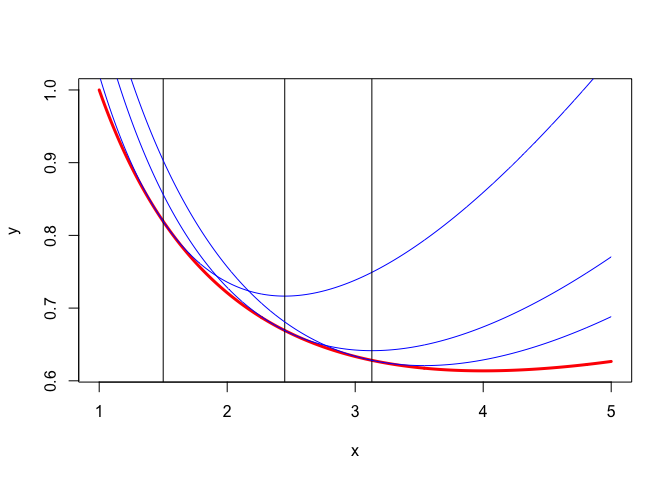

### 4.1.2 Majorizing Stress

## 4.2 Second Phase: Update Transformation

### 4.2.1 Spline Basis Details

*Splines* of degree $d$ on a closed interval $[a,b]$ are piecewise polynomials of degree $d$. The endpoints of the interval are the *boundary knots*. In the interval there are a number of *inner knots*. For smacof we suppose the inner knots are distinct. There is a polynomial piece between all consecutive pairs of knots. Although the pieces can be parts of different polynomials splines are required to have a certain degree of smoothness. In fact at the interior knots a spline has $d - 1$ continuous derivatives. A spline of degree zero is a step function, stepping to a different level at each knot. A spline of degree one is piecewise linear, where the line segments are joined continuously at the inner knots. A spline of degree two is piecewise quadratic and continuously differentiable at the knots. And so on. There is no limit on the number of inner knots and on the degree of the spline, although the number of interior knots must be greater than or equal to the degree minus one. The flexibility of the spline (as opposed to the rigidity of a polynomial on $[a,b]$ of the same degree) comes from the number and placement of the interior knots, not so much from the degree of the spline.

### 4.2.2 B-splines

### 4.2.3 Berstein PolynomiaLS

Table 4.1: B spline parameters

| degree | order | ninner | nknots | span |
| --- | --- | --- | --- | --- |
| 0 | 1 | 4 | 6 | 5 |
| 1 | 2 | 4 | 8 | 6 |
| 2 | 3 | 4 | 10 | 7 |
| 3 | 4 | 4 | 12 | 8 |
| 4 | 5 | 4 | 14 | 9 |

$$\sum_i B_{i,k}(x)=1$$

M-splines

$$M_{i,k}(x)=\frac{k+1}{t_{i+k+1}-t_i}B_{i,k}(X)$$
then
$$\int M_{i,k}(x)dx=1$$

I-splines
$$I_{i,k+1}(z)=\int_{-\infty}^zM_{i,k}(x)dx$$

It is sufficient that $\alpha_i\leq\alpha_{i+1}$

Integral, I-splines

### 4.2.4 Ordinal MDS

### 4.2.5 Interval and Ratio MDS

### 4.2.6 Cyclic Coordinate Decent

In the non-linear least squares (NNLS) problem the data are an $n\times p$ matrix $X$, a vector $y$ with $n$ elements, and a positive semi-definite diagonal matrix $W$. We want to minimize
$$\sigma(\beta):=\frac12(X\beta-y)'W(X\beta-y)$$
over $\beta\geq 0$. In data analysis and statistics the problem is often solved by *active set methods*, implemented in R for example by NNLS (Mullen and van Stokkum (2023)) and FNNLS (Bro and De Jong (1997)). Active set methods are finitely convergent dual methods. While iterating the intermediate solutions are not feasible (i.e. non-negative). In fact in dual methods we reach feasibility and optimality at the same time. Also the number of iterations, although theoretically finite, can be very large.

In each smacof iteration we need an NNLS solution. Especially in the early iterations the solution does not have to be very precise. Also the solution from the previous NNLS problem will generally provide a very good starting value for the next iteration (each NNLS problem has a “hot start”). And finally, we would like all internediate solutions to be feasible. These considerations have lead us to using *cyclic coordinate descent* (CCD).

Suppose the current best feasible solution in CCD iteration $k$ is $\beta^{(k)}$. The next CCD iteration changes each of the $p$ coordinates of $\beta^{(k)}$ in turn, maintaining feasibility, while keeping the other $p-1$ coordinates fixed at their current values. Thus within a CCD iteration $k$ we create intermediate solutions $\beta^{(k,1)},\cdots,\beta^{(k,p)}$, where each of the intermediate solutions $\beta^{(k,r)}$ differs from the previous one $\beta^{(k,r-1)}$ in a single coordinate. For consistency we define $\beta^{(k,0)}:=\beta^{(k)}$. After the iteration is finished we set $\beta^{(k+1)}=\beta^{(k,p)}$.

Note that in smacof each iteration modifies the coordinates in the order $1,\cdots,p$, which explains why the method is called “cyclic”. There are variations of CCD in which the order within an iteration is random or greedy (choose the coordinate which gives the largest improvement) or zig-zag $1,\cdots,p,p-1,\cdots,1$. We have not tried out these alternatives in smacf, but we may in the future.

The effect of changing a single coordinate on the loss function is
$$\sigma(\beta+\epsilon e_j)=\sigma(\beta)+\epsilon\ g_j(\beta)+\frac12\epsilon^2s_{jj},$$
where $e_j$ is the unit vector corresponding with the coordinate we are changing, $g(\beta):=\mathcal{D}\sigma(\beta)=X'Wr(\beta)$ is the gradient at $\beta$, and $r(\beta):=X\beta-y$ is the residual. Also $S:=X'WX$. Note that if $s_{jj}=0$ then also $g_j(\beta)=0$ and thus $\sigma(\beta+\epsilon e_j)=\sigma(\beta)$. In each CCD cycle we simply skip updating coordinate $j$.

If $s_{jj}>0$ then $\sigma(\beta+\epsilon e_j)$ is a strictly convex quadratic in $\epsilon$, which we must minimize under the constraint $\beta_j+\epsilon\geq 0$ or $\epsilon\geq-\beta_j$. Define $\hat\epsilon$ to be the solution of this constrained minimization problem.

One of the nice things about CCD is that
$$r(\hat\beta)=r(\beta)+\hat\epsilon x_j$$
$$g(\hat\beta)=g(\beta)+\hat\epsilon s_j$$

It follows that $\hat\epsilon=0$ if and only if either $\beta_j=0$ and $g_j(\beta)\geq 0$ or if $g_j(beta)=0$ and $beta_j>0$.

If $g_j(\beta)<0$ then $\tilde\epsilon>0$, and thus $\hat\epsilon>0$ and $\sigma(\hat\beta)<\sigma(\beta)$. Thus we must have $g_j(\beta)\geq 0$.

If $\beta_j>0$ and $g_j(\beta)\not=0$ then there is an $\epsilon$ such that $\sigma(\beta+\epsilon e_j)<\sigma(\beta)$. Thus if $\beta_j>0$ we must have $g_j(\beta)=0$.

In summary at the minimum of $\sigma$ over $\beta\geq 0$ we must have $\beta_j\geq 0$, $g_j(\beta)\geq 0$, and $\beta_jg_j(\beta)=0$ for all $j$ (*complementary slackness*).

$$\sigma(\beta+\epsilon e_j)=\sigma(\beta)+\epsilon\ g_j(\beta)+\frac12\epsilon^2s_{jj},$$
where $S:=X'WX$.

Now suppose we minimize $\sigma$ over $\beta\geq 0$.

Our best solution so far is $\beta^{(k)}\geq 0$. Minimize $\sigma(\beta^{(k)}+\epsilon e_1)$ over $\epsilon$ on the condition that $\beta^{(k)}_1+\epsilon\geq 0$ or $\epsilon\leq-\beta^{(k)}_1$. If $s_{11}=0$ then also $g_1(\beta)=0$ and we set $\beta^{(k+1,1)}=\beta^{(k,1)}$. If $s_{11}>0$ we compute
$$\tilde\epsilon=-g_1(\beta)/s_{11}$$
If
$$\beta^{(k)}_1+\tilde\epsilon\geq 0$$
then
$$\beta^{(k+1,1)}=\beta^{(k)}_1+\tilde\epsilon$$
If
$$\beta^{(k)}_1+\tilde\epsilon<0$$
we set
$$\beta^{(k+1,1)}=0.$$

# 5 Smacof Program

### 5.0.1 Front-end

The front-end for both smacofRR and smacofRC is written in R. The analysis is started in the user’s working directory by the command smacofRR(foo) or smacofRC(foo), where foo is a user-chosen name (without quotes).

Two text files need to be present in the working directory. The first is fooParameters.txt, where of course you substitute the user-chosen name for foo. The second file is fooDelta.txt, which has the dissimilarities below the diagonal in row-major order.

The parameter file has key-value format. Here is an example.

```r
nobj   9
ndim   3
init   2
width   10
precision   6
haveweights   0
itmax  1000
epsi  10
verbose  1
ditmax  5
depsi  6
dverbose  0
kitmax  5
kepsi  6
kverbose  0
degree  3
haveknots  3
ninner  5
ordinal  1
anchor 0
intercept  1
```

The parameter file is read first, using the R function read.table(). There is one key-value pair on each line, at the start of the line. The order of the lines does not matter. There can be additional comments or other text on each line after the value field, as long as that text is space-separated from the value field. Additional key-value lines with non-existing parameters can be added at will.

Values of the parameters are put the local environment using R function assign(), which means they are available to R throughout the smacof run. Of course if we choose smacofRC the front-end needs to pass them to C using C(), but they will be available again for the back-end.

The Delta file, and any subsequent optional input files, are read with the R function scan(). Values are separated by spaces. They can be on a single line, or laid out as a lower-triangular matrix, or whatever. The function scan() only stops reading if it reaches the end-of-file.

We’ll now discuss the parameters one by one. Note that all parameters are integers. The first two are obvious: *nobj* is the number of objects and *ndim* the number of dimensions. These two parameters have no default or recommended values, because they deyermined by the data. All other parameters in our example parameter file are set to reasonable values in our example parameter file. But the whole idea is to experiment with various combinations of parameter values, so “reasonable” is weaker than “recommended” and “recommended” is weaker than “default”.

The *init* parameter can have values 1, 2, or 3. If *init* equals 1 the program reads an initial configuration from the file fooXinit.txt in the working directory. The file has *nobj* * *ndim* numbers, the initial configuration, in row-major format. If *init* = 2 then the classical Torgerson initial estimate will be computed. If *init* = 3 a random initial estimate will be used.

*width* and *precision* are parameters for the output of the values of stress during iterations.

*haveweights* is either zero or one. If zero there are no weights, which is equivalent to all weights equal to one. If one then we will read a file fooWeights.txt, which has the lower-diagonal $\frac12 n(n-1)$ weights in row-major order.

The three final spline parameters are *ordinal*, *anchor*, and *intercept*. If *ordinal* is one the fitted spline is constrained to be monotone. If *intercept* is zero then the first spline coefficient is constrained to be zero (which means the first column is deleted from the basis). This means that the spline is constrained to be zero at the lower boundary knot. If *intercept* is one there is no such constraint, and the spline can be anything at the lower boundary (subject to monotonicity of *ordinal* is one). If *anchor* is one then the boundary knots are set to zero and the maximum dissimilarity, if *anchor* is zero the boundary knots are the minimum and maximum dissimilarity. Thus if *intercept* is zero and *anchor* is one the spline goes through the origin.

The computations in the frontend are straightforward. We first transform the dissimilarities linearly so that the smallest becomes zero and the largest becomes one. This is not strictly necessary but it makes the spline computations slightly easier.

Initial Estimates for $X$ Spline Basis

### 5.0.2 Engine

ALS First Phase Second Phase

### 5.0.3 Back-end

The back-end consists of a number of R functions that have the list returned by smacofRR or smacofRC as an argument. They can be used to make plots, compute derivatives, convert matrices to an easily printable format, do sensitivity analysis, and so on. The philosophy is that in the backend the main computing is finished and we just create different representations of the results.

#### 5.0.3.1 Plotting

There are two main plot functions in the backend: smacofShepardPlot() and smacofConfigurationPlot(). A smacofShepardPlot has the dissimilarities (un-normalized) on the horizontal axes and it has the distances and the disparities on the vertical axis. It draws the spline, and shows where the fitted disparities are on the spline. It also plots the (delta, dist) pairs as points, to show how far they deviate from the spline. Optionally smacofShepardPlot() can draw vertical lines at the inner knots (argument knotlines = TRUE), and optionally it can connect the (delta, dhat) points on the spline to the (delta, dist) points with lines (argument fitlines = TRUE).

It must be emphasized that smacofShepardPlot() draws the spline over the whole interval, which is either (deltamin, deltamax) if anchor = 0 and (0, deltamax) if anchor = 1. It does this by recomputing the spline at a large number of uniformly spaced points in the interval, where the number of points is given by the smacofShepardPlot() parameter resolution. Thus we do not use only the data points (delta,dhat) and then let the R plot function interpolate linearly. That can be misleading. It is especially misleading if degree is zero (step function) or if there are consecutive inner knots with no data values between the knots. Degree zero is handled by the special purpose step function plotting routine smacofPlotStepFunction(), which makes sure the spline is drawn as a horizontal segment from one knot to the next knot. In addition smacofShepardPlot() can set some base R plot parameters such as col, cex, lwd, and pch (see the R documentation).

The smacofConfigurationPlot() function is much simpler than smacofShepardPlot(). It sets pch, col, and cex. It uses the smacofRR/RC labels parameter to decide how to label the points in the configuration. If labels = 1 it reads a character vector of labels from fooLabels.txt, where foo is of course the name of the run. If labels = 2 the points are numbered, if labels = 3 plotting uses the pch symbol for all points. If the dimension $p$ is larger than two, smacofConfigurationPlot() uses the parameters dim1 and dim2 to select the dimensions to plot.

#### 5.0.3.2 Writing

#### 5.0.3.3 Checking

#### 5.0.3.4 Derivatives

#### 5.0.3.5 Sensitivity

Perturbation regions

Parametric Bootstrap

Jacknife

# 6 Examples

## 6.1 ekman

The Ekman (1954) color circle example has been used in many, if not most, multidimensional scaling textbooks and review articles. This is due, no doubt, to its astonishing good fit and its easy interpretability.

Four analyses this time, all monotone through the origin. In this case, because the minimum dissimilarity is zero anyway, the origin parameter has almost no effect.

## 6.3 morse

# 7 Tables

Table 7.1: Analyses of the ekman example

| ninner | degree | haveknots | ordinal | intercept | anchor | ndim | stress | itel |
| --- | --- | --- | --- | --- | --- | --- | --- | --- |
| 0 | 3 | 0 | 1 | 0 | 1 | 2 | 0.0021309760 | 39 |
| 5 | 3 | 3 | 1 | 0 | 1 | 2 | 0.0008780736 | 1260 |
| 50 | 0 | 3 | 1 | 0 | 1 | 2 | 0.0005138551 | 877 |
| 50 | 0 | 2 | 1 | 0 | 1 | 2 | 0.0010662271 | 492 |

# 8 Figures

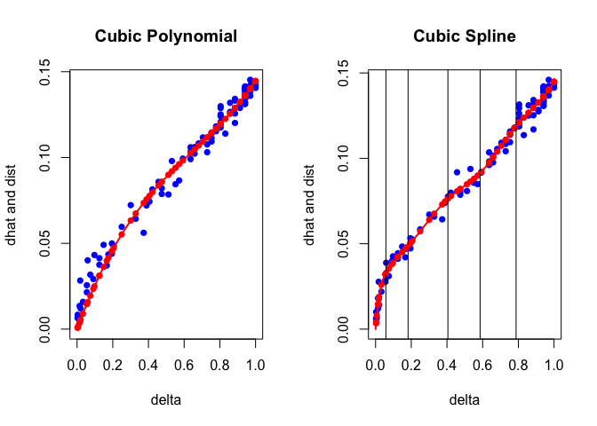

Figure 8.1: Ekman example, cubic analysis

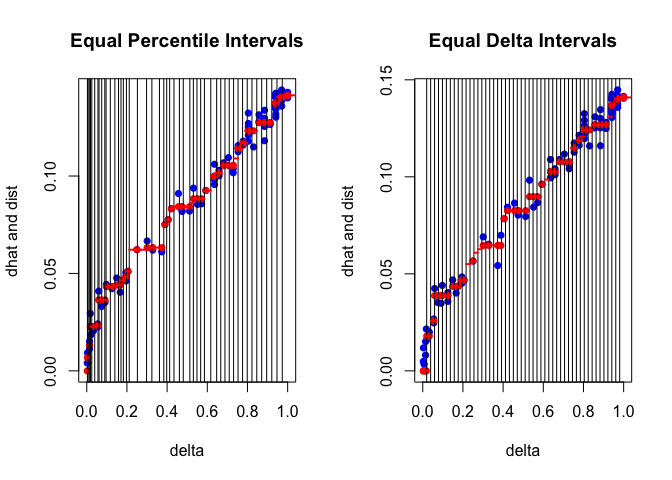

Figure 8.2: Ekman example, nonmetric analysis

# References

Bauschke, H. H., M. N. Bui, and X. Wang. 2018. “Projecting onto the Intersection of a Cone and a Sphere.” *SIAM Journal on Optimization* 28: 2158–88.

Böhning, D., and B. G. Lindsay. 1988. “Monotonicity of Quadratic-approximation Algorithms.” *Annals of the Institute of Statistical Mathematics* 40 (4): 641–63.

Bro, R., and S. De Jong. 1997. “A Fast Non-Negatively-Constrained Least Squares Algorithm.” *Journal of Chemometrics* 11: 393–401.

De Gruijter, D. N. M. 1967. “The Cognitive Structure of Dutch Political Parties in 1966.” Report E019-67. Psychological Institute, University of Leiden.

De Leeuw, J. 1975. “A Normalized Cone Regression Approach to Alternating Least Squares Algorithms.” Department of Data Theory FSW/RUL.

———. 1977. “Applications of Convex Analysis to Multidimensional Scaling.” In *Recent Developments in Statistics*, edited by J. R. Barra, F. Brodeau, G. Romier, and B. Van Cutsem, 133–45. Amsterdam, The Netherlands: North Holland Publishing Company.

———. 1984. “Differentiability of Kruskal’s Stress at a Local Minimum.” *Psychometrika* 49: 111–13.

———. 1994. “Block Relaxation Algorithms in Statistics.” In *Information Systems and Data Analysis*, edited by H. H. Bock, W. Lenski, and M. M. Richter, 308–24. Berlin: Springer Verlag. https://jansweb.netlify.app/publication/deleeuw-c-94-c/deleeuw-c-94-c.pdf.

———. 2014. “Bounding, and Sometimes Finding, the Global Minimum in Multidimensional Scaling.” UCLA Department of Statistics. https://jansweb.netlify.app/publication/deleeuw-u-14-b/deleeuw-u-14-b.pdf.

———. 2017a. “Pseudo Confidence Regions for MDS.” 2017. https://jansweb.netlify.app/publication/deleeuw-e-17-q/deleeuw-e-17-q.pdf.

———. 2017b. “Shepard Non-metric Multidimensional Scaling.” 2017. https://jansweb.netlify.app/publication/deleeuw-e-17-e/deleeuw-e-17-e.pdf.

———. 2019. “Normalized Cone Regression.” 2019. https://jansweb.netlify.app/publication/deleeuw-e-19-d/deleeuw-e-19-d.pdf.

De Leeuw, J., and P. Mair. 2009. “Multidimensional Scaling Using Majorization: SMACOF in R.” *Journal of Statistical Software* 31 (3): 1–30. https://www.jstatsoft.org/article/view/v031i03.

Dempster, A. P., N. M. Laird, and D. B. Rubin. 1977. “Maximum Likelihood for Incomplete Data via the EM Algorithm.” *Journal of the Royal Statistical Society* B39: 1–38.

Ekman, G. 1954. “Dimensions of Color Vision.” *Journal of Psychology* 38: 467–74.

Fang, H., and D. P. O’Leary. 2012. “Euclidean Distance Matrix Completion Problems Euclidean Distance Matrix Completion Problems Euclidean Distance Matrix Completion Problems.” *Oprtimization Methods and Software* 27 (4-5): 695–717.

Guttman, L. 1968. “A General Nonmetric Technique for Fitting the Smallest Coordinate Space for a Configuration of Points.” *Psychometrika* 33: 469–506.

Kruskal, J. B. 1964a. “Multidimensional Scaling by Optimizing Goodness of Fit to a Nonmetric Hypothesis.” *Psychometrika* 29: 1–27.

———. 1964b. “Nonmetric Multidimensional Scaling: a Numerical Method.” *Psychometrika* 29: 115–29.

Kruskal, J. B., and J. D. Carroll. 1969. “Geometrical Models and Badness of Fit Functions.” In *Multivariate Analysis, Volume II*, edited by P. R. Krishnaiah, 639–71. North Holland Publishing Company.

Lange, K. 2016. *MM Optimization Algorithms*. SIAM.

Le Thi, H. A., and P. D. Tao. 2018. “DC Programming and DCA: Thirty Years of Developments.” *Mathematical Programming, Series B*.

Mair, P., P. J. F. Groenen, and J. De Leeuw. 2022. “More on Multidimensional Scaling in R: smacof Version 2.” *Journal of Statistical Software* 102 (10): 1–47. https://www.jstatsoft.org/article/view/v102i10.

Mullen, K. M., and I. H. M. van Stokkum. 2023. *nnls: The Lawson-Hanson algorithm for non-negative least squares (NNLS)*. {https://CRAN.R-project.org/package=nnls}.

Niikolova, M., and M. Ng. 2005. “Analysis of Half-Quadratic Minimization Methods for Signal and Image Recovery.” *SIAM Journal Scientific Computing* 27 (3): 937–66.

Shepard, R. N. 1962a. “The Analysis of Proximities: Multidimensional Scaling with an Unknown Distance Function. I.” *Psychometrika* 27: 125–40.

———. 1962b. “The Analysis of Proximities: Multidimensional Scaling with an Unknown Distance Function. II.” *Psychometrika* 27: 219–46.

Vosz, H., and U. Eckhardt. 1980. “Linear Convergence of Generalized Weiszfeld’s Method.” *Computing* 25: 243–51.

Yuille, A. L., and A. Rangarajan. 2003. “The Concave-Convex Procedure.” *Neural Computation* 15: 915–36.

Zangwill, W. I. 1969. *Nonlinear Programming: a Unified Approach*. Englewood-Cliffs, N.J.: Prentice-Hall.